# How does the business of the Gym impact when I am going to train?

## Visual Data Story

In this visual data story I want to explore factors and observations I’ve made at the gym, and how they may potentially correlate with my choice to train on any given day, and what days I may be more likely to train than others.

## How did the mean number of benches differ depending if I trained or not?

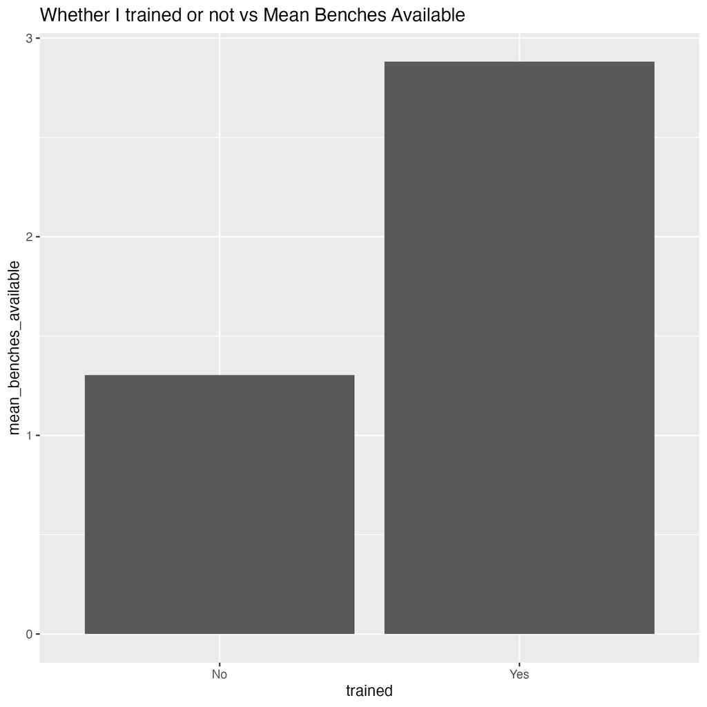

Plot of mean number of benches vs Trained or Not Trained

Here we see the plot that compares the mean number of benches on days that I train vs the mean number of benches on times that I did not train. From our graph, we can see a clear discrepancy - as the mean number of benches on instances when I was at the gym and trained is far greater than when I did not train. This highlights my tendency to train at times where the gym is evidently less busy, but we can also look at other trends as to when the gym may be less or more busy.

## How did the mean number of benches differ depending on whether Upper or Lower body was the majority?

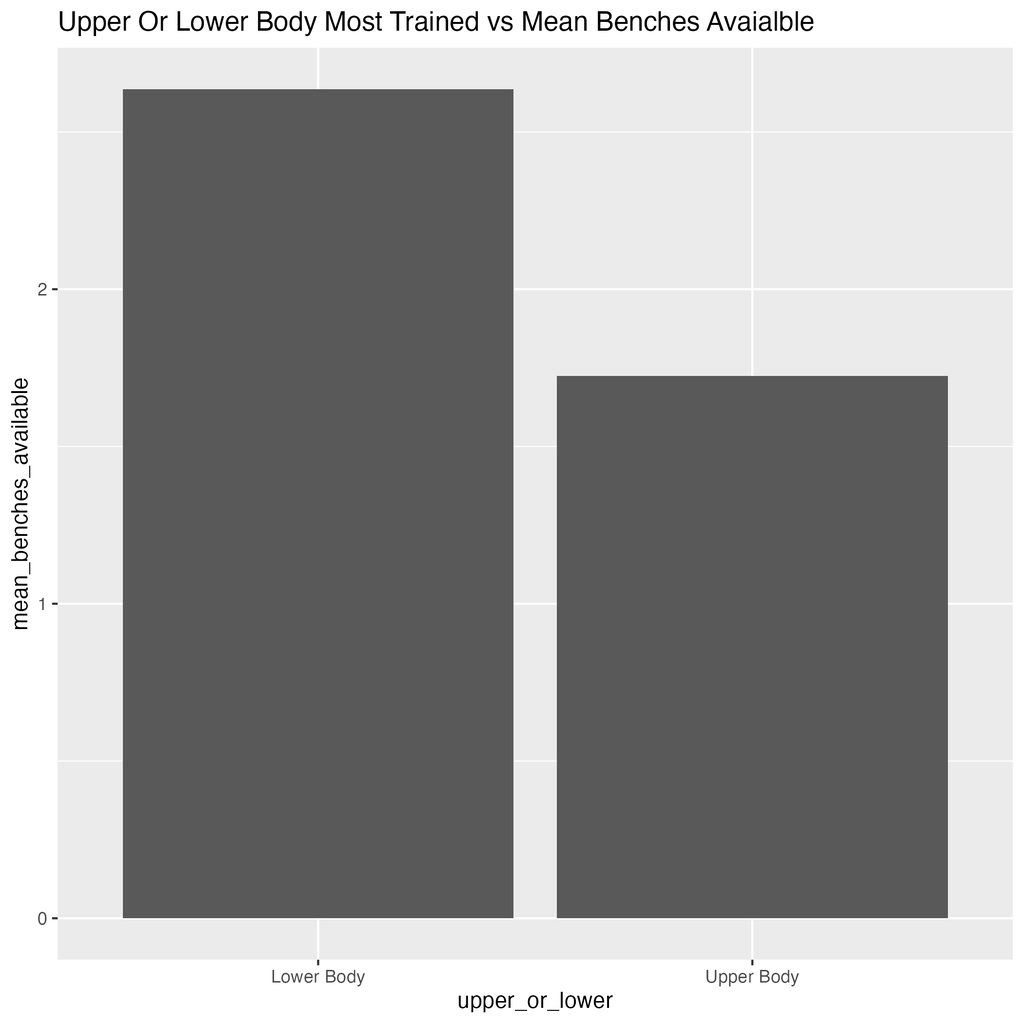

Plot of Mean Benches Available when Most people train upper vs lower

From this graph, we now see on days where most people were training upper body, the mean number of benches was far lower than on days where most people trained lower body. For this I considered Lower Body as days when Cardio / Legs were the dominant body group trained, and since neither exercise uses the benches often this could be a reason for this inherent difference. Another reason could be that days where lower body was trained tended to be days where fewer people were at the gym, meaning the gym was also simply less busy overall, resulting in the larger mean.

## A Representation of how many times I visited the gym each day.

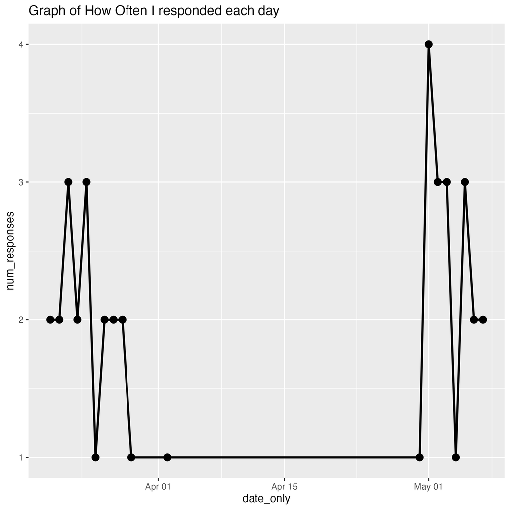

Attached here is a graph of how often I visited the gym on any given day, to get a more broad spectrum and better understand the habits of those at the gym.

## Findings

From this information, we can see that I was more likely to train on days where the predominant body group was lower body, as these tended to be the days where the largest number of benches was available. From my own point of view - I tend to train upper body far more than lower body, so this was relatively true, as I needed benches for far more of my exercises, so I was much more likely to train when I walked in and saw benches available. My findings tended to assume I trained on days where it was simply less busy.

## Were my findings accurate?

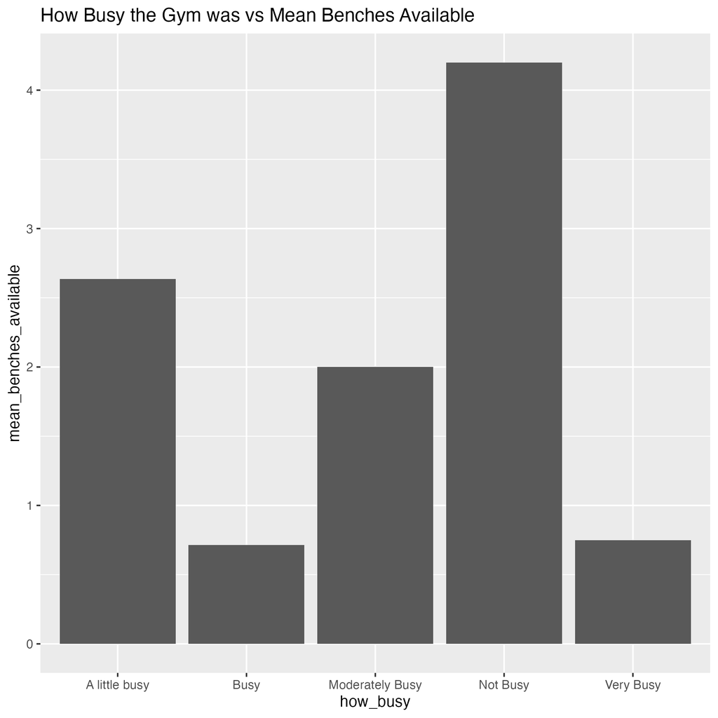

Plot of Mean Benches Available vs how busy it is

From this bar graph, we can see that days where more benches were available, the less busy it was, which means that our assumption that I was more likely to train on less busy days turned out to be correct.